# Sentiment analysis of danish newspapers in 1864

Julie, Marchus, Nikolaj og Ditte

```r
knitr::opts_chunk$set(echo = TRUE,
                      warning = FALSE,
                      message = FALSE)
```

# Installing packages

We install all the packages needed for doing textmining and sentiment analysis Becauce Sentida won´t install just by using install.packages code regardless of R version I use the devtools packages and get the package through a GitHub account. And open it through the library to see if done correctly.

```r
#install.packages("devtools")
#install.packages("usethis")

devtools::install_github("Guscode/Sentida")
library(devtools)
library(Sentida)
```

```r
#install.packages("here")
#install.packages("tidyverse")
#install.packages("pdftools")
#install.packages("qpdf")
#install.packages("tidytext")
#install.packages("tokenizers")
#install.packages("textdata")
#install.packages("ggwordcloud")
#install.packages("ggplot2")
#install.packages("ggplot2")
```

Then we open them trough the library

```r
library(tidyverse)
library(here)
library(dplyr)
library(qpdf)
library(textdata)
library(knitr)
library(here)
library(pdftools)
library(textdata)
library(tidytext)
library(ggwordcloud)
library(ggplot2)
```

# Upload data into R

We read the, in lapsapi created data into R

```r
all_data <- read.csv("https://labs.statsbiblioteket.dk/labsapi/api/aviser/export/fields?query=%28%22dybb%C3%B8l%22%20OR%20%22slesvig%22%20OR%20%22Als%22%20OR%20%22holsten%22%29%20AND%20%22krig%22%20AND%20py%3A1864&fields=link&fields=timestamp&fields=fulltext_org&fields=familyId&fields=lplace&max=-1&structure=header&structure=content&format=CSV")
```

# Gather the information we need from the dataset

We want to compare the newspapers published in Copenhagen vs. the newspapers published in Ribe, Tønder and Haderslev. From looking at the tibble of our dataset we know, that the column called lplace refers to the publication place of each newspaper therefore we create a dataset only with the data publication place = Copenhagen, which we can do by using the filter() and choosing “København” as our lplace. We define this dataset outcome as data_cph and load to see if done correctly and to see the data

```r
data_cph <- all_data %>%
  filter(lplace == "København")
```

We do the same to create a dataset only with the data publication place = Tønder, Haderslev and Ribe just by adding a | which stands for “and” and define this outcome as data_slw and again load to see if done correctly and to see the data

```r
data_slw <- filter(all_data, lplace=="Tønder" | lplace=="Haderslev" | lplace=="Ribe")
```

# Analysing the data

We now have two seperate datasets, one containing all the data published in Copenhagen and another one with all the data published in either Tønder, Ribe or Haderslev. For the Schleswig dataset we choose these 3 cities because of their location in the center of the happening and because of their dataamount. We now want to start by looking at our fulltext_org column, because it is the column on which we are going to work.

```r
all_data %>%
  select(fulltext_org)
```

[output not shown]

# Sentiment analyis

First, it is important to state that we choose not to remove any stopwords from our dataset. The reason behind is that we work with the package sentida, which analyses by using not only the analysed word, but also the context before and behind this word. Therefore, to get the best possible result, we choose not to remove any stopwords that possible could be a part of the context. As mentioned we use the sentida package. Here we compare the total value and the mean value from each dataset with each other.

```r
sentiment_slw_total <- data_slw$fulltext_org %>%
  sentida(output = "total")

sentiment_slw_mean <- data_slw$fulltext_org %>%
  sentida(output = "mean")
```

```r
sentiment_cph_total <- data_cph$fulltext_org %>%
  sentida(output = "total")

sentiment_cph_mean <- data_cph$fulltext_org %>%
  sentida(output = "mean")
```

#Comparison We load our environment to see the sentiment analysis, from which we are able to compare the two areas.

```r
sentiment_slw_total
```

```
## [1] -3.112722
```

```r
sentiment_slw_mean
```

```
## [1] -0.01814258
```

```r
sentiment_cph_total
```

```
## [1] 8.027179
```

```r
sentiment_cph_mean
```

```
## [1] 0.1244524
```

We see that the newspapers from the Schleswig region are much more negative than the ones published in Copenhagen.

# Visualization

We want to create a visualization that shows the amount of articles published in each location, based of the lplace column.

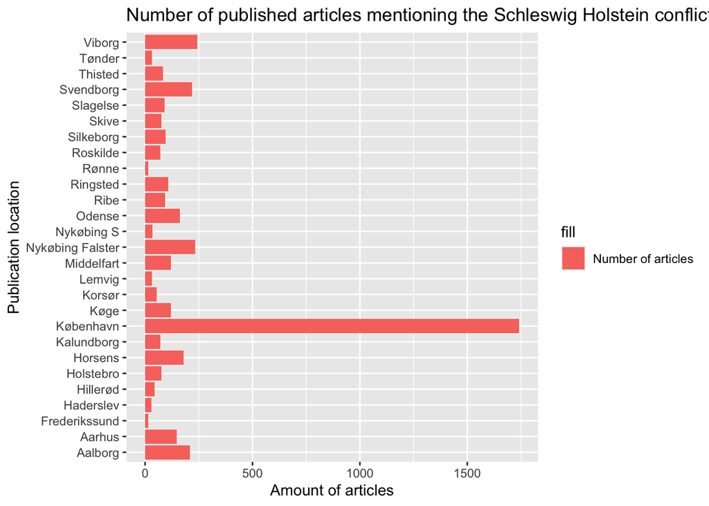

```r
ggplot(data = all_data, aes(y=lplace, fill= "Number of articles"))+
  geom_bar()+
  ggtitle("Number of published articles mentioning the Schleswig Holstein conflict in 1864")+
  xlab("Amount of articles")+
  ylab("Publication location")
```

Here we see that there are published a lot more in Copenhagen than in the other locations, which could effect the following visualizations.

# Visualization

We want to create a visualization that shows the individually newspapers sentiment value. For this we need to separate the slw dataset into three datasets.

```r
data_tonder <- filter(all_data, lplace == "Tønder")
data_haderslev <- filter(all_data, lplace == "Haderslev")
data_ribe <- filter(all_data, lplace == "Ribe")

sentiment_tonder <- sentida(data_tonder$fulltext_org, output = "mean")
sentiment_haderslev <- sentida(data_haderslev$fulltext_org, output = "mean")
sentiment_ribe <- sentida(data_ribe$fulltext_org, output = "mean")
```

# Visualization

Then we use ggplot to create the visualization and choose some colors

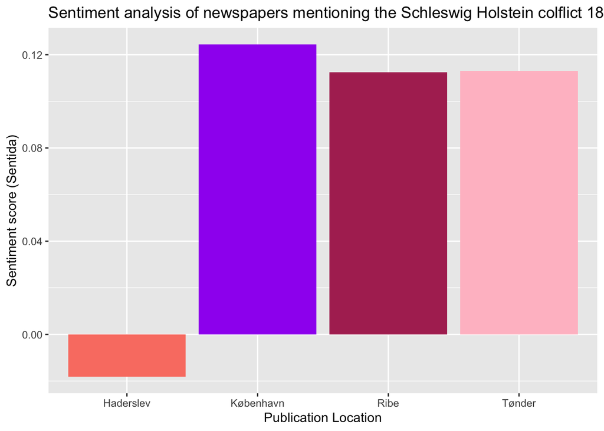

```r
ggplot() +
  geom_col(aes(x = "Tønder", y = sentiment_tonder), fill = "pink")+
  geom_col(aes(x = "Ribe", y = sentiment_ribe), fill = "maroon")+
  geom_col(aes(x = "Haderslev", y = sentiment_haderslev), fill = "salmon")+
  geom_col(aes(x = "København", y = sentiment_cph_mean), fill = "purple")+
  ggtitle("Sentiment analysis of newspapers mentioning the Schleswig Holstein colflict 1864")+
  xlab("Publication Location")+
  ylab("Sentiment score (Sentida)")
```

From this visualization we can see that the most positive mention comes from the regions Copenhagen, Tønder and Ribe and that the most negative mention comes from Haderslev.

# Loading datasets from 1862, 1866 and 1868

Because we wish to see how the publishing amount and the sentiment analysis evolve throughout the years before and after our 1864 period, we load three other datasets from respectively 1862, 1866 and 1868.

```r
all_data_1862 <- read.csv("https://labs.statsbiblioteket.dk/labsapi/api/aviser/export/fields?query=%28%22dybb%C3%B8l%22%20OR%20%22slesvig%22%20OR%20%22Als%22%20OR%20%22holsten%22%29%20AND%20%22krig%22%20AND%20py%3A1862&fields=link&fields=timestamp&fields=fulltext_org&fields=familyId&fields=lplace&max=-1&structure=header&structure=content&format=CSV")
```

```r
all_data_1866 <- read_csv("https://labs.statsbiblioteket.dk/labsapi/api/aviser/export/fields?query=%28%22dybb%C3%B8l%22%20OR%20%22slesvig%22%20OR%20%22Als%22%20OR%20%22holsten%22%29%20AND%20%22krig%22%20AND%20py%3A1866&fields=link&fields=timestamp&fields=fulltext_org&fields=familyId&fields=lplace&max=-1&structure=header&structure=content&format=CSV")
```

```r
all_data_1868 <- read_csv("https://labs.statsbiblioteket.dk/labsapi/api/aviser/export/fields?query=%28%22dybb%C3%B8l%22%20OR%20%22slesvig%22%20OR%20%22Als%22%20OR%20%22holsten%22%29%20AND%20%22krig%22%20AND%20py%3A1868&fields=link&fields=timestamp&fields=fulltext_org&fields=familyId&fields=lplace&max=-1&structure=header&structure=content&format=CSV")
```

To create a visualization, we need the sentiment values in a separate column, which we can create with the lapply() function

```r
all_data_1862$sentiment <- lapply(all_data_1862$fulltext_org,sentida, output = "mean")
all_data$sentiment <- lapply(all_data$fulltext_org,sentida, output = "mean")
all_data_1866$sentiment <- lapply(all_data_1866$fulltext_org,sentida, output = "mean")
all_data_1868$sentiment <- lapply(all_data_1868$fulltext_org,sentida, output = "mean")
```

# Visualization

Now we create a visualization showing the amount of published articles in the individually years

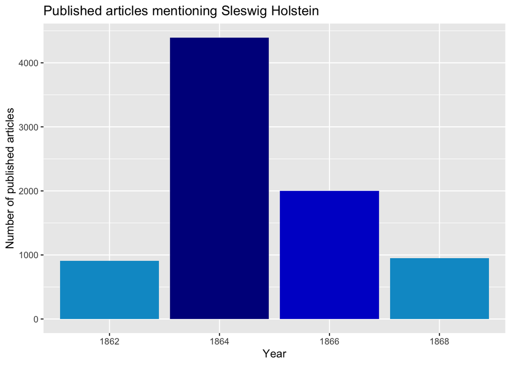

```r
ggplot()+
  geom_col(aes(x = "1862", y = nrow(all_data_1862)), fill = "deepskyblue3")+
  geom_col(aes(x = "1864", y = nrow(all_data)), fill = "blue4")+
  geom_col(aes(x = "1866", y = nrow(all_data_1866)), fill = "blue3")+
  geom_col(aes(x = "1868", y = nrow(all_data_1868)), fill = "deepskyblue3")+
  ggtitle("Published articles mentioning Sleswig Holstein")+
  xlab("Year")+
  ylab("Number of published articles")
```

From which we see that publishing amount of articles mentioning Schleswig Holstein conflict is highest in the year of happening and lowest in the years before and gradually decreases in the years following.